# Best Subset Selection

# Best Subset Selection for Regression Models

[Back to Homepage](https://alexisidlettewilson.github.io/)

The Best Subset Selection approach considers every possible combination of features and creates a model for each one. Using one’s chosen evaluation statistic, one can select the model with the best results.

Best Subset Selection is likely overfit so ideally we use evaluation statistics that estimate the test error for each model. In the analysis below, Mallow’s Cp is used.

The data set includes baseball player statistics and salaries.

```r
library(ISLR)
summary(Hitters)
```

```
     AtBat            Hits           HmRun            Runs             RBI
 Min.   : 19.0   Min.   :  1.0   Min.   : 0.00   Min.   :  0.00   Min.   :  0.00
 1st Qu.:282.5   1st Qu.: 71.5   1st Qu.: 5.00   1st Qu.: 33.50   1st Qu.: 30.00
 Median :413.0   Median :103.0   Median : 9.00   Median : 52.00   Median : 47.00
 Mean   :403.6   Mean   :107.8   Mean   :11.62   Mean   : 54.75   Mean   : 51.49
 3rd Qu.:526.0   3rd Qu.:141.5   3rd Qu.:18.00   3rd Qu.: 73.00   3rd Qu.: 71.00
 Max.   :687.0   Max.   :238.0   Max.   :40.00   Max.   :130.00   Max.   :121.00
     Walks            Years            CAtBat            CHits
 Min.   :  0.00   Min.   : 1.000   Min.   :   19.0   Min.   :   4.0
 1st Qu.: 23.00   1st Qu.: 4.000   1st Qu.:  842.5   1st Qu.: 212.0
 Median : 37.00   Median : 6.000   Median : 1931.0   Median : 516.0
 Mean   : 41.11   Mean   : 7.312   Mean   : 2657.5   Mean   : 722.2
 3rd Qu.: 57.00   3rd Qu.:10.000   3rd Qu.: 3890.5   3rd Qu.:1054.0
 Max.   :105.00   Max.   :24.000   Max.   :14053.0   Max.   :4256.0
     CHmRun           CRuns             CRBI            CWalks       League  Division
 Min.   :  0.00   Min.   :   2.0   Min.   :   3.0   Min.   :   1.0   A:139   E:129
 1st Qu.: 15.00   1st Qu.: 105.5   1st Qu.:  95.0   1st Qu.:  71.0   N:124   W:134
 Median : 40.00   Median : 250.0   Median : 230.0   Median : 174.0
 Mean   : 69.24   Mean   : 361.2   Mean   : 330.4   Mean   : 260.3
 3rd Qu.: 92.50   3rd Qu.: 497.5   3rd Qu.: 424.5   3rd Qu.: 328.5
 Max.   :548.00   Max.   :2165.0   Max.   :1659.0   Max.   :1566.0
    PutOuts          Assists          Errors           Salary       NewLeague
 Min.   :   0.0   Min.   :  0.0   Min.   : 0.000   Min.   :  67.5   A:141
 1st Qu.: 113.5   1st Qu.:  8.0   1st Qu.: 3.000   1st Qu.: 190.0   N:122
 Median : 224.0   Median : 45.0   Median : 7.000   Median : 425.0
 Mean   : 290.7   Mean   :118.8   Mean   : 8.593   Mean   : 535.9
 3rd Qu.: 322.5   3rd Qu.:192.0   3rd Qu.:13.000   3rd Qu.: 750.0
 Max.   :1377.0   Max.   :492.0   Max.   :32.000   Max.   :2460.0
```

There are 59 missing values in the Salary variable we want to predict. I decide to remove this observations. The function *na.omit* removes all incomplete observations

```r
Hitters <- na.omit(Hitters)
```

To check that *na.omit* worked, I use the *anyNA* function to quickly determine if there are any NA fields.

```r
anyNA(Hitters$Salary)
```

```
[1] FALSE
```

## Best Subset Regression

I use the package `leaps` to evaluate all the best-subset models.

```r
install.packages("leaps")
```

```
Error in install.packages : Updating loaded packages
```

```r
library(leaps)
```

The `leaps` function *regsubsets* runs the best subset regression. The `~.` tells R to create the models with all features except Salary.

```r
bestregfit.full <- regsubsets(Salary~., data = Hitters)
summary(bestregfit.full)
```

```
Subset selection object
Call: regsubsets.formula(Salary ~ ., data = Hitters)
19 Variables  (and intercept)
           Forced in Forced out
AtBat          FALSE      FALSE
Hits           FALSE      FALSE
HmRun          FALSE      FALSE
Runs           FALSE      FALSE
RBI            FALSE      FALSE
Walks          FALSE      FALSE
Years          FALSE      FALSE
CAtBat         FALSE      FALSE
CHits          FALSE      FALSE
CHmRun         FALSE      FALSE
CRuns          FALSE      FALSE
CRBI           FALSE      FALSE
CWalks         FALSE      FALSE
LeagueN        FALSE      FALSE
DivisionW      FALSE      FALSE
PutOuts        FALSE      FALSE
Assists        FALSE      FALSE
Errors         FALSE      FALSE
NewLeagueN     FALSE      FALSE
1 subsets of each size up to 8
Selection Algorithm: exhaustive
         AtBat Hits HmRun Runs RBI Walks Years CAtBat CHits CHmRun CRuns CRBI CWalks
1  ( 1 ) " "   " "  " "   " "  " " " "   " "   " "    " "   " "    " "   "*"  " "
2  ( 1 ) " "   "*"  " "   " "  " " " "   " "   " "    " "   " "    " "   "*"  " "
3  ( 1 ) " "   "*"  " "   " "  " " " "   " "   " "    " "   " "    " "   "*"  " "
4  ( 1 ) " "   "*"  " "   " "  " " " "   " "   " "    " "   " "    " "   "*"  " "
5  ( 1 ) "*"   "*"  " "   " "  " " " "   " "   " "    " "   " "    " "   "*"  " "
6  ( 1 ) "*"   "*"  " "   " "  " " "*"   " "   " "    " "   " "    " "   "*"  " "
7  ( 1 ) " "   "*"  " "   " "  " " "*"   " "   "*"    "*"   "*"    " "   " "  " "
8  ( 1 ) "*"   "*"  " "   " "  " " "*"   " "   " "    " "   "*"    "*"   " "  "*"
         LeagueN DivisionW PutOuts Assists Errors NewLeagueN
1  ( 1 ) " "     " "       " "     " "     " "    " "
2  ( 1 ) " "     " "       " "     " "     " "    " "
3  ( 1 ) " "     " "       "*"     " "     " "    " "
4  ( 1 ) " "     "*"       "*"     " "     " "    " "
5  ( 1 ) " "     "*"       "*"     " "     " "    " "
6  ( 1 ) " "     "*"       "*"     " "     " "    " "
7  ( 1 ) " "     "*"       "*"     " "     " "    " "
8  ( 1 ) " "     "*"       "*"     " "     " "    " "
```

The summary indicates only eight features were modeled in subsets as that is the default. I run it again with the full number of features, 19.

```r
bestregfit.full19 <- regsubsets(Salary~., data = Hitters, nvmax=19)
summary(bestregfit.full19)
```

```
Subset selection object
Call: regsubsets.formula(Salary ~ ., data = Hitters, nvmax = 19)
19 Variables  (and intercept)
           Forced in Forced out
AtBat          FALSE      FALSE
Hits           FALSE      FALSE
HmRun          FALSE      FALSE
Runs           FALSE      FALSE
RBI            FALSE      FALSE
Walks          FALSE      FALSE
Years          FALSE      FALSE
CAtBat         FALSE      FALSE
CHits          FALSE      FALSE
CHmRun         FALSE      FALSE
CRuns          FALSE      FALSE
CRBI           FALSE      FALSE
CWalks         FALSE      FALSE
LeagueN        FALSE      FALSE
DivisionW      FALSE      FALSE
PutOuts        FALSE      FALSE
Assists        FALSE      FALSE
Errors         FALSE      FALSE
NewLeagueN     FALSE      FALSE
1 subsets of each size up to 19
Selection Algorithm: exhaustive
          AtBat Hits HmRun Runs RBI Walks Years CAtBat CHits CHmRun CRuns CRBI CWalks
1  ( 1 )  " "   " "  " "   " "  " " " "   " "   " "    " "   " "    " "   "*"  " "
2  ( 1 )  " "   "*"  " "   " "  " " " "   " "   " "    " "   " "    " "   "*"  " "
3  ( 1 )  " "   "*"  " "   " "  " " " "   " "   " "    " "   " "    " "   "*"  " "
4  ( 1 )  " "   "*"  " "   " "  " " " "   " "   " "    " "   " "    " "   "*"  " "
5  ( 1 )  "*"   "*"  " "   " "  " " " "   " "   " "    " "   " "    " "   "*"  " "
6  ( 1 )  "*"   "*"  " "   " "  " " "*"   " "   " "    " "   " "    " "   "*"  " "
7  ( 1 )  " "   "*"  " "   " "  " " "*"   " "   "*"    "*"   "*"    " "   " "  " "
8  ( 1 )  "*"   "*"  " "   " "  " " "*"   " "   " "    " "   "*"    "*"   " "  "*"
9  ( 1 )  "*"   "*"  " "   " "  " " "*"   " "   "*"    " "   " "    "*"   "*"  "*"
10  ( 1 ) "*"   "*"  " "   " "  " " "*"   " "   "*"    " "   " "    "*"   "*"  "*"
11  ( 1 ) "*"   "*"  " "   " "  " " "*"   " "   "*"    " "   " "    "*"   "*"  "*"
12  ( 1 ) "*"   "*"  " "   "*"  " " "*"   " "   "*"    " "   " "    "*"   "*"  "*"
13  ( 1 ) "*"   "*"  " "   "*"  " " "*"   " "   "*"    " "   " "    "*"   "*"  "*"
14  ( 1 ) "*"   "*"  "*"   "*"  " " "*"   " "   "*"    " "   " "    "*"   "*"  "*"
```

[output cut: 10 more lines]

```
5  ( 1 )  " "     "*"       "*"     " "     " "    " "
6  ( 1 )  " "     "*"       "*"     " "     " "    " "
7  ( 1 )  " "     "*"       "*"     " "     " "    " "
8  ( 1 )  " "     "*"       "*"     " "     " "    " "
9  ( 1 )  " "     "*"       "*"     " "     " "    " "
10  ( 1 ) " "     "*"       "*"     "*"     " "    " "
11  ( 1 ) "*"     "*"       "*"     "*"     " "    " "
12  ( 1 ) "*"     "*"       "*"     "*"     " "    " "
13  ( 1 ) "*"     "*"       "*"     "*"     "*"    " "
14  ( 1 ) "*"     "*"       "*"     "*"     "*"    " "
15  ( 1 ) "*"     "*"       "*"     "*"     "*"    " "
16  ( 1 ) "*"     "*"       "*"     "*"     "*"    " "
17  ( 1 ) "*"     "*"       "*"     "*"     "*"    "*"
18  ( 1 ) "*"     "*"       "*"     "*"     "*"    "*"
19  ( 1 ) "*"     "*"       "*"     "*"     "*"    "*"
```

Let’s view the compnents provided in the summary.

```r
names(summary(bestregfit.full19))
```

```
[1] "which"  "rsq"    "rss"    "adjr2"  "cp"     "bic"    "outmat" "obj"
```

I plot the Cp (Mallow’s Cp) component to determine which model has the lowest Cp.

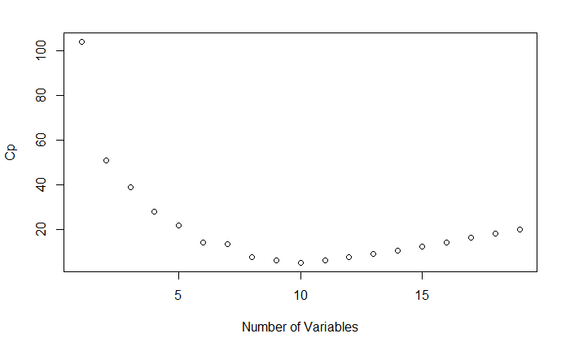

```r
bestregfit.summary <- summary(bestregfit.full19)
plot(bestregfit.summary$cp, xlab="Number of Variables", ylab="Cp")
```

The model with 10 variables appears to have the lowest Cp. I can also query this specifically with *which.min*

```r
which.min(bestregfit.summary$cp)
```

```
[1] 10
```

I’m going to mark the lowest point on my plot.

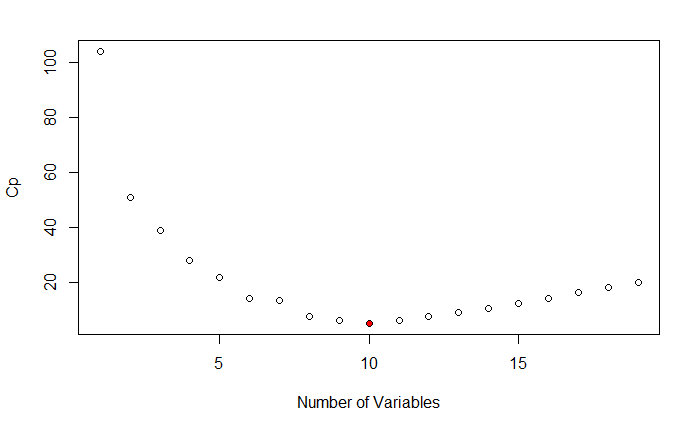

```r
plot(bestregfit.summary$cp, xlab="Number of Variables", ylab="Cp")
points(10, bestregfit.summary$cp[10], pch=20, col="red")
```

I can also plot `regsubsets` object itself.

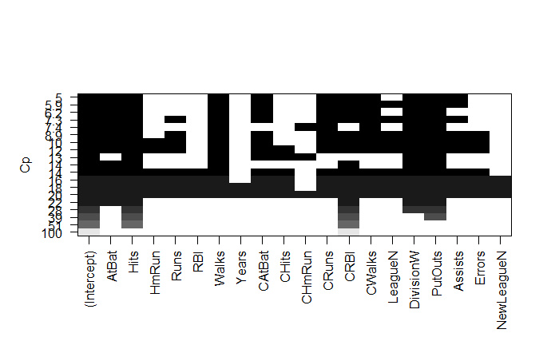

```r
plot(bestregfit.full19, scale="Cp")
```

We can finally get the coefficients for the 10 variables in that best model.

```r
coef(bestregfit.full19, 10)
```

```
 (Intercept)        AtBat         Hits        Walks       CAtBat        CRuns
 162.5354420   -2.1686501    6.9180175    5.7732246   -0.1300798    1.4082490
        CRBI       CWalks    DivisionW      PutOuts      Assists
   0.7743122   -0.8308264 -112.3800575    0.2973726    0.2831680
```